# Colibactin WI sample RNA-Seq analysis, combined batch 1+2 - GSEA analysis on averaged DGE results

Hilmar Berger

27 November, 2019 12:28:59

```r
rm(list=ls())

suppressMessages(library(xlsx))
library(reshape2)
library(pheatmap)
library(ggplot2)
library(knitr)
library(scales)
library(fgsea)
library(readxl)
library(data.table)
library(BiocParallel)

result_folder = "../../../../Results/RNASeq"
if (!file.exists(result_folder)) dir.create(result_folder, recursive=T)

set.seed(12334)
```

# 1 Overview

We here run GSEA on DGE results from the Colibactin infection WI sample RNASeq. For analysis, a preranked analysis using the R package fGSEA is used that should give similar results to preranked analysis in standard GSEA.

# 2 MSigDB

Since MSigDB gene sets use human gene symbols to map genes to pathways we will translate mouse symbols to homologous human symbols using HomologeneDB from NCBI (build 68).

```r
b1 = new.env()
b2 = new.env()

load(file.path(result_folder, "DGE_analysis_image_batch1.Rdata"), envir=b1)
load(file.path(result_folder, "DGE_analysis_image_batch2.Rdata"), envir=b2)

all_dge_results = c(get("all_results", b1), get("all_results",b2))

tmp = merge(all_dge_results[["WI_Pool_vs_uninfected"]], all_dge_results[["M2_WI_vs_uninfected"]], by="Row.names")
tmp = merge(tmp, all_dge_results[["M3_WI_vs_uninfected"]], by="Row.names")
tmp$log2FoldChange_avg = apply(tmp[, c("log2FoldChange", "log2FoldChange.x", "log2FoldChange.y")], 1, mean, na.rm=T)
all_results = list()
all_results[["log2FC_avg_WI_vs_NI"]] = tmp
all_results[["M1_WI_vs_uninfected"]] = all_dge_results[["WI_Pool_vs_uninfected"]]
all_results[["M2_WI_vs_uninfected"]] = all_dge_results[["M2_WI_vs_uninfected"]]
all_results[["M3_WI_vs_uninfected"]] = all_dge_results[["M3_WI_vs_uninfected"]]
```

```r
gsea_gmt_folder = "../../../../Data/External/GeneSets/MSigDB_v6.2/"
gsea_gmt_files = c("h.all.v6.2.symbols.gmt","c2.all.v6.2.symbols.gmt","c3.all.v6.2.symbols.gmt","c5.bp.v6.2.symbols.gmt","c6.all.v6.2.symbols.gmt","c7.all.v6.2.symbols.gmt")
names(gsea_gmt_files) = c("HALLMARK","PATHWAYS","MOTIF","GO_BP","ONCOGENIC","IMMUNOLOGIC")
gset_collections_human = list()
for (n in names(gsea_gmt_files)) {
  gset_collections_human[[n]] = gmtPathways(paste(gsea_gmt_folder, gsea_gmt_files[[n]], sep="/") )
}
```

We use the following gene sets from MSigDB.

```r
gsea_gmt_files
```

```
##                  HALLMARK                  PATHWAYS
##  "h.all.v6.2.symbols.gmt" "c2.all.v6.2.symbols.gmt"
##                     MOTIF                     GO_BP
## "c3.all.v6.2.symbols.gmt"  "c5.bp.v6.2.symbols.gmt"
##                 ONCOGENIC               IMMUNOLOGIC
## "c6.all.v6.2.symbols.gmt" "c7.all.v6.2.symbols.gmt"
```

# 3 Other gene sets

- Munoz et al Small Intestinal Stem Cell Signature (PMID: 22692129, DOI: 10.1038/emboj.2012.166, Supp Table S3 )
- From Barker et al 2010 we include the SC signature of stomach antral Lgr5 cells
- Herbst et al Beta-catenine target genes (human, PMID: 24467841)
- Gene sets based on RNASeq-Data published by Riemer et al (JCB 2017, https://doi.org/10.1083/jcb.201610058 ). RNAseq data was downloaded, quantified with Salmon and analysed with DESeq2. For both CTNNB1stab and PIK3CAmut conditions, genes expressed significantly differential between transgene and control with log2FC < -1 or > 1 were selected as down and up-regulated.

```r
known_genes = unique(all_results[[1]]$GeneSymbol)

custom_gene_sets_human = list()

beta_cat_genes = as.data.frame(read_excel("../../../../Data/External/GeneSets/Wnt target H2014 list.xls", sheet = 1, col_names = F))
custom_gene_sets_human[["Herbst_et_al_Beta_catenin_targets"]] = unique(beta_cat_genes[, 1])

gset_collections_human[["CUSTOM"]] = custom_gene_sets_human

####################################################################

custom_gene_sets_mouse = list()

tmp = read.table("../../../../Data/External/GeneSets/Supp_Table_S3_GE_combined_SC_Signature.txt", sep="\t", header=T, stringsAsFactors = F)
custom_gene_sets_mouse[["Lgr5_SC_Signature_Munoz"]] = unique(tmp$GeneSymbol)

tmp = as.data.frame(read_excel("../../../../Data/External/GeneSets/antral lgr5 signature from barker 2010.xls",sheet=1))
custom_gene_sets_mouse[["Barker_Antral_SC"]] = unique(tmp[2:nrow(tmp),1])

riemer_ctnnb1_vs_control = read.table("../../../../Data/External/GeneSets/Differential_expression_results_CTNNB1_KI_vs_Control.txt", sep="\t", header=T, stringsAsFactors = F, quote = "")

riemer_pik3_vs_control = read.table("../../../../Data/External/GeneSets/Differential_expression_results_PIK3mut_vs_Control.txt", sep="\t", header=T, stringsAsFactors = F, quote="")

custom_gene_sets_mouse[["CTNNB1stab_up_Riemer"]] = subset(riemer_ctnnb1_vs_control, padj < 0.05 & log2FoldChange > 1 )$GeneSymbol

custom_gene_sets_mouse[["CTNNB1stab_down_Riemer"]] = subset(riemer_ctnnb1_vs_control, padj < 0.05 & log2FoldChange < -1 )$GeneSymbol

custom_gene_sets_mouse[["PIK3mut_up_Riemer"]] = subset(riemer_pik3_vs_control, padj < 0.05 & log2FoldChange > 1 )$GeneSymbol

custom_gene_sets_mouse[["PIK3mut_down_Riemer"]] = subset(riemer_pik3_vs_control, padj < 0.05 & log2FoldChange < -1 )$GeneSymbol

gset_collections_mouse = list(CUSTOM_MOUSE=custom_gene_sets_mouse)
```

## 3.1 fGSEA Analysis of MsigDB Gene Set

```r
homologene_human_mouse = fread("../../../../Data/External/homologene_9606_10090.txt")
all_entrez_ids = data.frame(EntrezID=unique(all_results[[1]]$EntrezID))
all_symbols = data.frame(GeneSymbol=unique(all_results[[1]]$GeneSymbol))
a1 = merge(all_symbols, homologene_human_mouse[,c("entrez_1","symbol_1","symbol_2"), with=F], by.x="GeneSymbol", by.y="symbol_2", all.x=T, sort=F)

mouse_to_human=a1
rownames(mouse_to_human) = mouse_to_human$GeneSymbol
```

```r
data_generation_date = "2019-11"
output_folder = result_folder
GSEA_datafile = paste(output_folder,"fGSEA_Results.Rdata",sep="/")
if (!file.exists(output_folder)) dir.create(output_folder, recursive=T)

rerun_GSEA = TRUE

if(rerun_GSEA) {
  all_gsea_results = list()
  n_perm = 5000
  n_proc = 8
  bpparam = MulticoreParam(worker=n_proc, manager.hostname="127.0.0.1")
  for (n in names(all_results)) {
    print(paste("Running FGSEA for comparison",n))
    gsea_result_tables = list()
    tmp = subset(all_results[[n]], !is.na(GeneSymbol)) # those are mostly control probes

    tmp2 = merge(tmp, mouse_to_human, by="GeneSymbol")
    tmp2 = subset(tmp2, !is.na(symbol_1))
    ranks = unlist(tapply(tmp2$log2FoldChange, tmp2$symbol_1, function(x) x[which(abs(x)==max(abs(x)))] ))

    for (gs in names(gset_collections_human)) {
      print(gs)
      fgseaRes <- fgsea(gset_collections_human[[gs]], ranks, minSize=15, maxSize=2000, nperm=n_perm, BPPARAM=bpparam)
      fgseaRes$GeneSetCollection = gs
      gsea_result_tables[[gs]] = fgseaRes
    }

    results_human = do.call(rbind, gsea_result_tables)

    gsea_result_tables_mouse = list()
    ranks_mouse = unlist(tapply(tmp$log2FoldChange, tmp$GeneSymbol, function(x) x[which(abs(x)==max(abs(x)))] ))

    for (gs in names(gset_collections_mouse)) {
       print(gs)
       fgseaRes <- fgsea(gset_collections_mouse[[gs]], ranks_mouse, minSize=15, maxSize=2000, nperm=n_perm, BPPARAM=bpparam)
       fgseaRes$GeneSetCollection = gs
       gsea_result_tables_mouse[[gs]] = fgseaRes
    }

    results_mouse = do.call(rbind, gsea_result_tables_mouse)
    results_all = rbind(results_human, results_mouse)
    results_all$FDR_global = p.adjust(results_all$pval, "BH")

    all_gsea_results[[n]] = results_all
  }
  save(all_gsea_results, file=GSEA_datafile)
  save(gset_collections_human, gset_collections_mouse, file=file.path(output_folder, "Geneset_collections.Rdata"))
} else {
  load(GSEA_datafile)
}
```

```
## [1] "Running FGSEA for comparison log2FC_avg_WI_vs_NI"
## [1] "HALLMARK"
## [1] "PATHWAYS"
## [1] "MOTIF"
## [1] "GO_BP"
## [1] "ONCOGENIC"
## [1] "IMMUNOLOGIC"
## [1] "CUSTOM"
## [1] "CUSTOM_MOUSE"
## [1] "Running FGSEA for comparison M1_WI_vs_uninfected"
## [1] "HALLMARK"
## [1] "PATHWAYS"
## [1] "MOTIF"
## [1] "GO_BP"
## [1] "ONCOGENIC"
```

[output cut: 21 more lines]

Result files are written to folder ../../../../Results/RNASeq

We export all gene sets with less than 10% FDR after global adjustment of p-values per sample.

```r
FDR_threshold = 0.1
if(rerun_GSEA) {
  output_file_prefix = paste(result_folder,"fGSEA_Results_", sep="/")
  for (n in names(all_gsea_results)) {
    filename = paste(output_file_prefix, n, ".txt", sep="" )
    tmp = all_gsea_results[[n]]
    tmp$direction= ifelse(tmp$NES > 0, "Up","Down")
    tmp = tmp[order(tmp$NES, decreasing=T),]
    tmp$leadingEdge = unlist(lapply(tmp$leadingEdge, function(x) paste(x, collapse=",")))
    tmp = subset(tmp, FDR_global < FDR_threshold)
    col_order = c("pathway","GeneSetCollection","direction","pval","padj","ES","NES","nMoreExtreme","size","leadingEdge", "FDR_global")
    write.table(tmp[,col_order, with=F], file= filename, row.names=F , sep="\t", dec=".", quote=F, na="")
  }
}
```

```r
if(rerun_GSEA) {
  output_file_prefix = paste(result_folder,"fGSEA_Results_all_comparisons", sep="/")
  agr = list()
  for (n in names(all_gsea_results)) {
    tmp = all_gsea_results[[n]]
    tmp$direction= ifelse(tmp$NES > 0, "Up","Down")
    tmp = tmp[order(tmp$NES, decreasing=T),]
    tmp$leadingEdge = unlist(lapply(tmp$leadingEdge, function(x) paste(x, collapse=",")))
    tmp = subset(tmp, padj < 0.05)
    col_order = c("pathway","GeneSetCollection","direction","pval","padj","ES","NES","nMoreExtreme","size","leadingEdge")
    tmp$Comparison = n
    agr[[n]] = tmp
  }

  agr_combined = do.call(rbind, agr)

  filename = paste(output_file_prefix, ".txt", sep="" )
  write.table(agr_combined, file= filename, row.names=F , sep="\t", dec=".", quote=F, na="")
}
```

## 3.2 Result overview

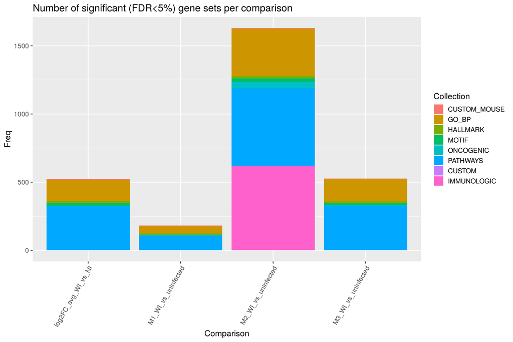

```r
gsea_summary = list()
for (n in names(all_gsea_results)) {
  tmp = subset(all_gsea_results[[n]], padj < 0.05)
  r = as.data.frame(table(tmp$GeneSetCollection, ifelse(tmp$ES<0, "Down","Up")))
  colnames(r) = c("Collection","Direction","Freq")
  r$Comparison = n
  gsea_summary[[n]] = r
}

gsea_summary_df = do.call(rbind, gsea_summary)

ggplot(gsea_summary_df, aes(x=Comparison, y = Freq, fill=Collection)) + geom_bar(stat="identity") + theme_grey(base_size = 14) + theme(axis.text.x = element_text(angle = 60, hjust = 1)) + ggtitle("Number of significant (FDR<5%) gene sets per comparison")
```

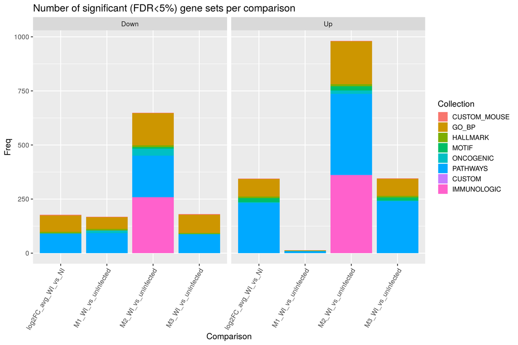

```r
ggplot(gsea_summary_df, aes(x=Comparison, y = Freq, fill=Collection)) + geom_bar(stat="identity") + theme_grey(base_size = 14) + theme(axis.text.x = element_text(angle = 60, hjust = 1)) + ggtitle("Number of significant (FDR<5%) gene sets per comparison") + facet_wrap(~Direction)
```

# 4 Software version used